# **Mitron Bank - Credit Card Allocation Analysis**

### 📌 Objective: Identify customers eligible for credit cards based on spending behavior.

### 📊 Dataset: Includes customer details (dim_customer) & spending patterns (fact_spend).

## **1️⃣ Importing Required Libraries**

We first import necessary Python libraries such as Pandas, NumPy, Matplotlib, and Seaborn for data analysis and visualization.

## **2️⃣ Data Loading & Overview**

We load the datasets and explore the first few rows to understand the structure.

## **3️⃣ Data Cleaning & Preprocessing**

Handling missing values, removing duplicates, and formatting columns for consistency.

## **4️⃣ Exploratory Data Analysis (EDA)**

Visualizing customer spending trends, income distribution, and identifying key patterns.

## **5️⃣ Graphs & Insights**

Key visualizations used in the analysis.

## **6️⃣ Conclusion & Credit Card Allocation Strategy**

Based on the analysis, we identify key customer segments suitable for credit card allocation. Factors considered: **High Utilization %, Consistent Spending, and Income Stability.**

# Importing required library

```python
import pandas as pd
import numpy as np
import matplotlib.pyplot as plt
import seaborn as sns
from matplotlib.patches import FancyBboxPatch
import matplotlib.ticker as mticker
```

# Importing Data

```python
df_dim = pd.read_csv('dim_customers.csv')
df_fact = pd.read_csv('fact_spends.csv')

dim_customer = pd.DataFrame(df_dim)
fact_spends = pd.DataFrame(df_fact)
```

# Data Cleaning & Preprocessing

### Checking NULL & DUPLICATE values

##### Data - dim_customer

```python
dim_customer.info()
```

```
<class 'pandas.core.frame.DataFrame'>
RangeIndex: 4000 entries, 0 to 3999
Data columns (total 7 columns):
 #   Column          Non-Null Count  Dtype
---  ------          --------------  -----
 0   customer_id     4000 non-null   object
 1   age_group       4000 non-null   object
 2   city            4000 non-null   object
 3   occupation      4000 non-null   object
 4   gender          4000 non-null   object
 5   marital status  4000 non-null   object
 6   avg_income      4000 non-null   int64
dtypes: int64(1), object(6)
memory usage: 218.9+ KB
```

```python
dim_customer.head(25)
```

|  | customer_id | age_group | city | occupation | gender | marital status | avg_income |
| --- | --- | --- | --- | --- | --- | --- | --- |
| 0 | ATQCUS1825 | 45+ | Bengaluru | Salaried IT Employees | Male | Married | 73523 |
| 1 | ATQCUS0809 | 25-34 | Hyderabad | Salaried Other Employees | Male | Married | 39922 |
| 2 | ATQCUS0663 | 25-34 | Chennai | Salaried Other Employees | Male | Married | 37702 |
| 3 | ATQCUS0452 | 25-34 | Delhi NCR | Government Employees | Male | Married | 54090 |
| 4 | ATQCUS3350 | 21-24 | Bengaluru | Freelancers | Male | Single | 28376 |
| 5 | ATQCUS3256 | 21-24 | Delhi NCR | Salaried IT Employees | Male | Single | 46586 |
| 6 | ATQCUS3608 | 25-34 | Chennai | Freelancers | Male | Single | 34966 |
| 7 | ATQCUS0611 | 25-34 | Chennai | Salaried IT Employees | Male | Married | 59078 |
| 8 | ATQCUS3856 | 21-24 | Bengaluru | Salaried Other Employees | Female | Single | 30424 |
| 9 | ATQCUS2640 | 35-45 | Delhi NCR | Salaried IT Employees | Female | Married | 67450 |
| 10 | ATQCUS3008 | 45+ | Mumbai | Government Employees | Female | Married | 62542 |
| 11 | ATQCUS2365 | 25-34 | Chennai | Salaried IT Employees | Female | Married | 62738 |
| 12 | ATQCUS1141 | 35-45 | Delhi NCR | Business Owners | Male | Married | 72301 |
| 13 | ATQCUS2853 | 35-45 | Chennai | Business Owners | Female | Married | 74783 |
| 14 | ATQCUS3020 | 45+ | Delhi NCR | Salaried IT Employees | Female | Married | 73754 |
| 15 | ATQCUS2442 | 25-34 | Chennai | Government Employees | Female | Married | 54575 |
| 16 | ATQCUS3943 | 25-34 | Delhi NCR | Salaried IT Employees | Female | Single | 60269 |
| 17 | ATQCUS1679 | 45+ | Mumbai | Salaried Other Employees | Male | Married | 41845 |
| 18 | ATQCUS0744 | 25-34 | Chennai | Freelancers | Male | Married | 33831 |
| 19 | ATQCUS3335 | 21-24 | Bengaluru | Business Owners | Male | Single | 54149 |
| 20 | ATQCUS0846 | 25-34 | Hyderabad | Business Owners | Male | Married | 68634 |
| 21 | ATQCUS2462 | 25-34 | Hyderabad | Salaried IT Employees | Female | Married | 65608 |
| 22 | ATQCUS0916 | 35-45 | Mumbai | Salaried IT Employees | Male | Married | 63264 |
| 23 | ATQCUS3766 | 21-24 | Mumbai | Salaried IT Employees | Female | Single | 47229 |
| 24 | ATQCUS1285 | 35-45 | Bengaluru | Business Owners | Male | Married | 74263 |

```python
dim_customer.describe()
```

|  | avg_income |
| --- | --- |
| count | 4000.000000 |
| mean | 51657.032250 |
| std | 14690.140645 |
| min | 24816.000000 |
| 25% | 38701.000000 |
| 50% | 50422.000000 |
| 75% | 64773.250000 |
| max | 86600.000000 |

```python
dim_customer.isnull().sum()
```

```
customer_id       0
age_group         0
city              0
occupation        0
gender            0
marital status    0
avg_income        0
dtype: int64
```

```python
dim_customer[dim_customer.duplicated()]
```

|  | customer_id | age_group | city | occupation | gender | marital status | avg_income |
| --- | --- | --- | --- | --- | --- | --- | --- |

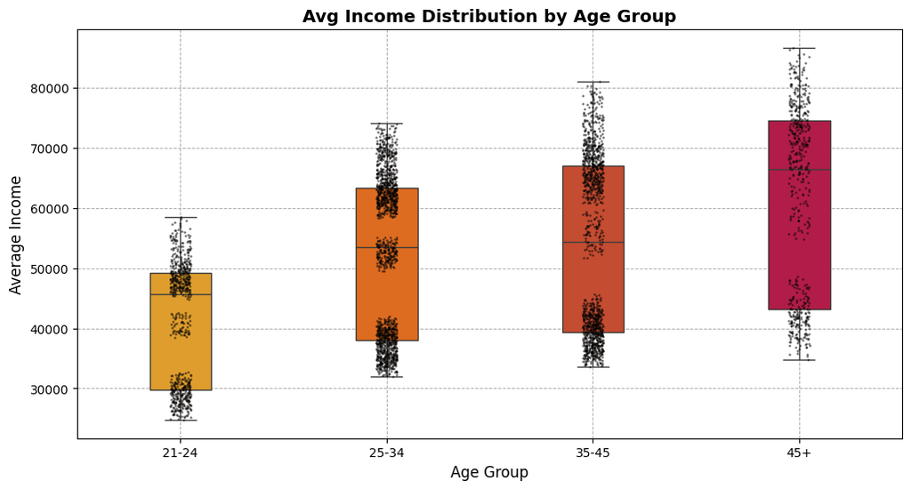

```python
plt.figure(figsize=(12, 6))

rocket_palette = ['#FDA50F','#FC6600','#DC3C18','#CA033E']

order = ['21-24','25-34','35-45','45+']

# Apply rocket colors to the boxplot
box = sns.boxplot(x=dim_customer['age_group'], y=dim_customer['avg_income'], width=0.3, palette=rocket_palette,order = order)

# Stripplot remains black for contrast
sns.stripplot(x=dim_customer['age_group'], y=dim_customer['avg_income'],
              alpha=0.6, color='#070504', size=1.8, jitter=0.05)

# Add grid
plt.grid(True, which='major', linestyle='--', linewidth=0.7, alpha=1)

# Title and labels
plt.title("Avg Income Distribution by Age Group", fontsize=14, fontweight='bold')
plt.xlabel("Age Group", fontsize=12)
plt.ylabel("Average Income", fontsize=12)

# Show plot
plt.show()
```

### **📊 Boxplot (Avg Income vs. Age Group)**

**Insight:** Income increases with age, suggesting that older customers generally earn more.

The income range varies across age groups, with the widest variation in the 35-45 and 45+ groups.

##### Data - fact_spends

```python
fact_spends.info()
```

```
<class 'pandas.core.frame.DataFrame'>
RangeIndex: 864000 entries, 0 to 863999
Data columns (total 5 columns):
 #   Column        Non-Null Count   Dtype
---  ------        --------------   -----
 0   customer_id   864000 non-null  object
 1   month         864000 non-null  object
 2   category      864000 non-null  object
 3   payment_type  864000 non-null  object
 4   spend         864000 non-null  int64
dtypes: int64(1), object(4)
memory usage: 33.0+ MB
```

```python
fact_spends.head(10)
```

|  | customer_id | month | category | payment_type | spend |
| --- | --- | --- | --- | --- | --- |
| 0 | ATQCUS1371 | July | Health & Wellness | Credit Card | 1114 |
| 1 | ATQCUS0368 | October | Groceries | Credit Card | 1466 |
| 2 | ATQCUS0595 | May | Health & Wellness | Credit Card | 387 |
| 3 | ATQCUS0667 | October | Electronics | Credit Card | 1137 |
| 4 | ATQCUS3477 | September | Bills | UPI | 2102 |
| 5 | ATQCUS1972 | October | Health & Wellness | UPI | 243 |
| 6 | ATQCUS2843 | June | Entertainment | Credit Card | 268 |
| 7 | ATQCUS2634 | August | Apparel | Debit Card | 737 |
| 8 | ATQCUS2165 | July | Food | UPI | 506 |
| 9 | ATQCUS0908 | September | Others | UPI | 380 |

```python
fact_spends.describe()
```

|  | spend |
| --- | --- |
| count | 864000.000000 |
| mean | 614.464994 |
| std | 661.571676 |
| min | 6.000000 |
| 25% | 191.000000 |
| 50% | 395.000000 |
| 75% | 793.000000 |
| max | 10313.000000 |

```python
fact_spends[fact_spends.duplicated()]
```

|  | customer_id | month | category | payment_type | spend |
| --- | --- | --- | --- | --- | --- |

```python
customer_spends = pd.merge(fact_spends , dim_customer , on = 'customer_id')
```

```python
customer_spends.head(10)
```

|  | customer_id | month | category | payment_type | spend | age_group | city | occupation | gender | marital status | avg_income |
| --- | --- | --- | --- | --- | --- | --- | --- | --- | --- | --- | --- |
| 0 | ATQCUS1371 | July | Health & Wellness | Credit Card | 1114 | 35-45 | Chennai | Salaried IT Employees | Male | Married | 64696 |
| 1 | ATQCUS1371 | May | Bills | UPI | 787 | 35-45 | Chennai | Salaried IT Employees | Male | Married | 64696 |
| 2 | ATQCUS1371 | September | Bills | Net Banking | 1022 | 35-45 | Chennai | Salaried IT Employees | Male | Married | 64696 |
| 3 | ATQCUS1371 | September | Bills | UPI | 1942 | 35-45 | Chennai | Salaried IT Employees | Male | Married | 64696 |
| 4 | ATQCUS1371 | August | Electronics | Credit Card | 1865 | 35-45 | Chennai | Salaried IT Employees | Male | Married | 64696 |
| 5 | ATQCUS1371 | October | Travel | Net Banking | 149 | 35-45 | Chennai | Salaried IT Employees | Male | Married | 64696 |
| 6 | ATQCUS1371 | October | Others | Credit Card | 280 | 35-45 | Chennai | Salaried IT Employees | Male | Married | 64696 |
| 7 | ATQCUS1371 | August | Travel | Net Banking | 186 | 35-45 | Chennai | Salaried IT Employees | Male | Married | 64696 |
| 8 | ATQCUS1371 | August | Groceries | Net Banking | 440 | 35-45 | Chennai | Salaried IT Employees | Male | Married | 64696 |
| 9 | ATQCUS1371 | July | Travel | Net Banking | 163 | 35-45 | Chennai | Salaried IT Employees | Male | Married | 64696 |

##### In this step below we are adding a new column called 'utilisation_%' to customer_spends dataset.

##### The 'utilisation_%' column represent the percentage of a customer's spending relative to their availabel income. This metric helps in understanding spending behavior and financial utilisation patterns among different customer segments.

```python
customer_spends['utilisation_%'] = (customer_spends.apply(lambda x: x['spend']/x['avg_income'], axis = 1))*100
customer_spends
```

|  | customer_id | month | category | payment_type | spend | age_group | city | occupation | gender | marital status | avg_income | utilisation_% |
| --- | --- | --- | --- | --- | --- | --- | --- | --- | --- | --- | --- | --- |
| 0 | ATQCUS1371 | July | Health & Wellness | Credit Card | 1114 | 35-45 | Chennai | Salaried IT Employees | Male | Married | 64696 | 1.721899 |
| 1 | ATQCUS1371 | May | Bills | UPI | 787 | 35-45 | Chennai | Salaried IT Employees | Male | Married | 64696 | 1.216459 |
| 2 | ATQCUS1371 | September | Bills | Net Banking | 1022 | 35-45 | Chennai | Salaried IT Employees | Male | Married | 64696 | 1.579696 |
| 3 | ATQCUS1371 | September | Bills | UPI | 1942 | 35-45 | Chennai | Salaried IT Employees | Male | Married | 64696 | 3.001731 |
| 4 | ATQCUS1371 | August | Electronics | Credit Card | 1865 | 35-45 | Chennai | Salaried IT Employees | Male | Married | 64696 | 2.882713 |
| ... | ... | ... | ... | ... | ... | ... | ... | ... | ... | ... | ... | ... |
| 863995 | ATQCUS0890 | October | Groceries | Net Banking | 764 | 35-45 | Mumbai | Salaried IT Employees | Male | Married | 65187 | 1.172013 |
| 863996 | ATQCUS0890 | September | Health & Wellness | Debit Card | 1188 | 35-45 | Mumbai | Salaried IT Employees | Male | Married | 65187 | 1.822449 |
| 863997 | ATQCUS0890 | September | Electronics | UPI | 2786 | 35-45 | Mumbai | Salaried IT Employees | Male | Married | 65187 | 4.273858 |
| 863998 | ATQCUS0890 | August | Groceries | Debit Card | 2593 | 35-45 | Mumbai | Salaried IT Employees | Male | Married | 65187 | 3.977787 |
| 863999 | ATQCUS0890 | August | Groceries | UPI | 3074 | 35-45 | Mumbai | Salaried IT Employees | Male | Married | 65187 | 4.715664 |

864000 rows × 12 columns

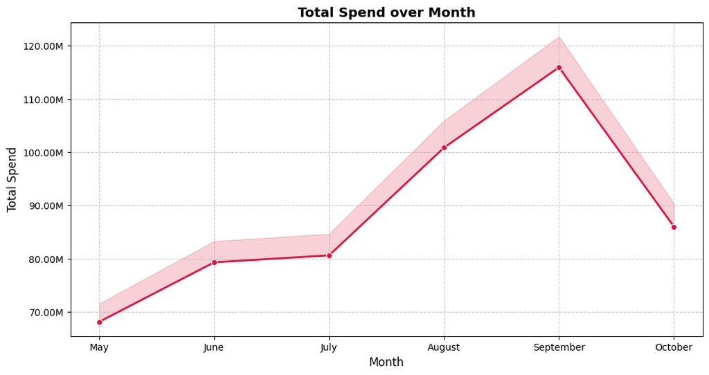

```python
# Define the correct order for months
month_order = ["May", "June", "July", "August", "September", "October"]

# Convert 'month' column to categorical type with the correct order
customer_spends['month'] = pd.Categorical(customer_spends['month'], categories=month_order, ordered=True)

# Aggregate total spend per month
monthly_spend = customer_spends.groupby("month")["spend"].sum().reset_index()

x_values = np.arange(len(monthly_spend["month"]))
y_values = monthly_spend["spend"]

# Plot the line chart
plt.figure(figsize=(12, 6))
sns.lineplot(x="month", y="spend", data=monthly_spend, marker="o", color="crimson", linewidth=2)

plt.fill_between(x_values, y_values * 1.05, y_values * 1, color="crimson", alpha=0.2)

# Formatting Y-axis to show values in Millions (M)
ax = plt.gca()
ax.yaxis.set_major_formatter(mticker.FuncFormatter(lambda x, _: f"{x/1_000_000:.2f}M"))

# Title and labels
plt.title("Total Spend over Month", fontsize=14, fontweight='bold')
plt.xlabel("Month", fontsize=12)
plt.ylabel("Total Spend", fontsize=12)

# Add grid for better readability
plt.grid(True, linestyle="--", alpha=0.7)

# Show plot
plt.show()
```

### **📊 Line Chart (Month vs Total Spend)**

**Insight:** The trend shows a gradual increase in spending from May to September, peaking in September, followed by a decline in October.

This could indicate seasonal spending patterns or specific events driving higher expenditures in certain months.

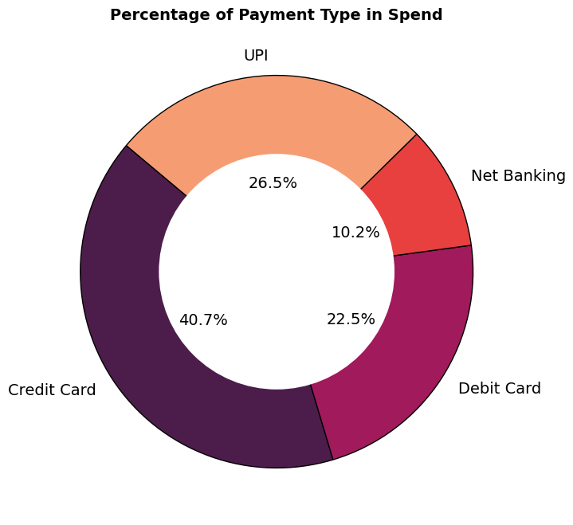

```python
# Aggregate Spend by Payment Type
payment_spend = customer_spends.groupby("payment_type")["spend"].sum()

# Get Labels & Values
labels = payment_spend.index
sizes = payment_spend.values

# Get 'rocket' color palette from Seaborn
num_colors = len(labels)  # Ensure we get the exact number of colors needed
colors = sns.color_palette("rocket", num_colors)

# Create Donut Chart
plt.figure(figsize=(8, 8))

plt.pie(sizes, labels=labels, autopct='%1.1f%%', colors=colors, startangle=140,
        wedgeprops={'edgecolor': 'black'}, textprops={'fontsize': 14}, pctdistance=0.45)

# Add White Circle in Center for Donut Effect
center_circle = plt.Circle((0, 0), 0.60, fc='white')
plt.gca().add_artist(center_circle)

# Title and labels
plt.title("Percentage of Payment Type in Spend", fontsize=14, fontweight='bold')
plt.show()
```

### **📊 Donut Chart (Total Spend % through Payment Type)**

**Insight:** Credit Cards dominate transactions with 40.7% of total spend, followed by UPI (26.5%) and Debit Cards (22.5%).

Net Banking has the least share (10.2%), indicating a preference for card-based and digital transactions over traditional online banking.

This insight can help Mitron Bank in designing better credit card offers and UPI-based incentives to encourage more spending.

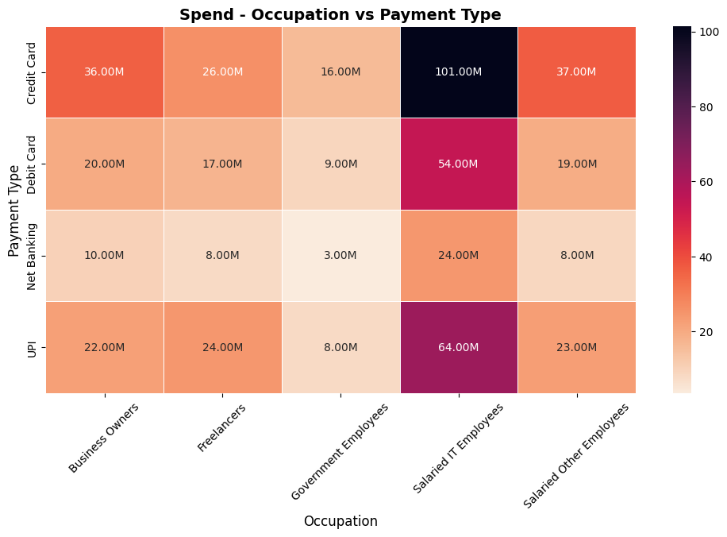

```python
order = ['May','June','July','August','September','October']

# Convert 'month' column to categorical with a specific order
customer_spends["month"] = pd.Categorical(customer_spends["month"],ordered=True)

# Step 1: Aggregate total spend per category per month
category_month_spend = customer_spends.groupby(["payment_type", "occupation"])["spend"].sum().reset_index()

category_month_spend["spend"] = category_month_spend["spend"] / 1_000_000

# Step 2: Pivot data for heatmap format
pivot_table = category_month_spend.pivot(index="payment_type", columns="occupation", values="spend").fillna(0)

# Step 3: Plot heatmap
plt.figure(figsize=(12, 6))
ax = sns.heatmap(pivot_table, cmap="rocket_r", annot=True, fmt=".0f", linewidths=0.5)

for text in ax.texts:
    text.set_text(f"{float(text.get_text()):.2f}M")

# Title and labels
plt.title("Spend - Occupation vs Payment Type", fontsize=14, fontweight='bold')
plt.xlabel("Occupation",fontsize=12)
plt.ylabel("Payment Type",fontsize=12)
plt.xticks(rotation=45)

plt.show()
```

### **📊 Heatmap (Total Spend across different payment Categories for various Occupation)**

**Insight:** IT Employees spend the most using Credit Cards (101M) and UPI (64M), highlighting their digital payment preference.

Business Owners also have significant spending on Credit Cards (36M) and UPI (22M).

Net Banking is the least preferred payment mode, showing relatively lower values across all customer categories.

This data helps in targeting high-spending customer segments with tailored financial products and marketing strategies.

**Note:** The following annotation function is used to label bar heights in millions for better readability in the chart. Instead of displaying raw numbers, it formats values in millions (M) by dividing them by 1,000,000 and rounding them to the nearest whole number.

```python
def annotation(ax, scale=1000000, fmt='{:.0f}M'):
    for p in ax.patches:
        ax.annotate(f'{p.get_height()/1000000:.0f}M',
        (p.get_x() + p.get_width() / 2., p.get_height()),
        ha='center', va='bottom',
        xytext=(0, 5), textcoords='offset points')
```

```python
def annotation_h(ax, fmt='{:.0f}M'):
    for p in ax.patches:
        ax.annotate(f'{p.get_width():.0f}M',
                    (p.get_width(), p.get_y() + p.get_height() / 2.),
                    ha='left', va='center',
                    xytext=(5, 0), textcoords='offset points')
```

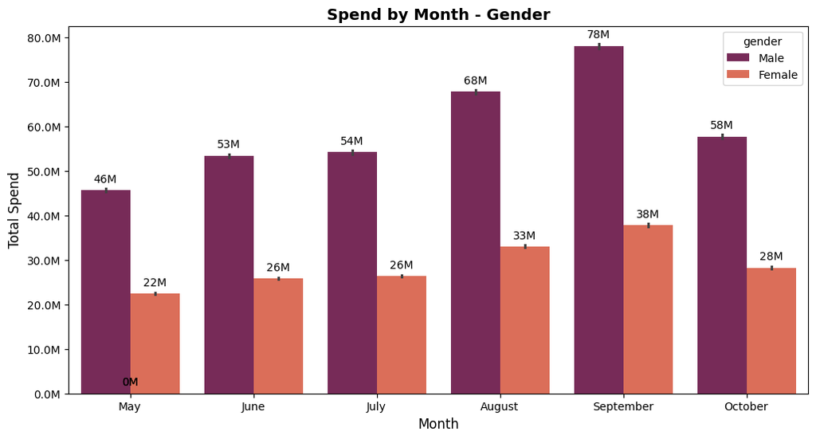

```python
plt.figure(figsize = (12,6))

order = ['May','June','July','August','September','October']

ax = sns.barplot(data = customer_spends , x = 'month' , y = 'spend' ,
                 estimator = sum , hue = 'gender', palette = 'rocket', order = order)

ax.yaxis.set_major_formatter(mticker.FuncFormatter(lambda x, _: f'{x/1_000_000:.1f}M'))

annotation(ax)

# Title and labels
plt.title("Spend by Month - Gender", fontsize=14, fontweight='bold')
plt.xlabel("Month", fontsize=12)
plt.ylabel("Total Spend", fontsize=12)
plt.show()
```

### **📊 Grouped Bar Chart (Total Spend by Gender across different Months)**

**Insight:** Male customers consistently spend more than female customers in all months.

September recorded the highest spending for both genders, with Males at 78M and Females at 38M.

Spending by females shows a gradual increase from May to September but drops in October.

Male spending also peaks in September but remains significantly higher than female spending throughout the months.

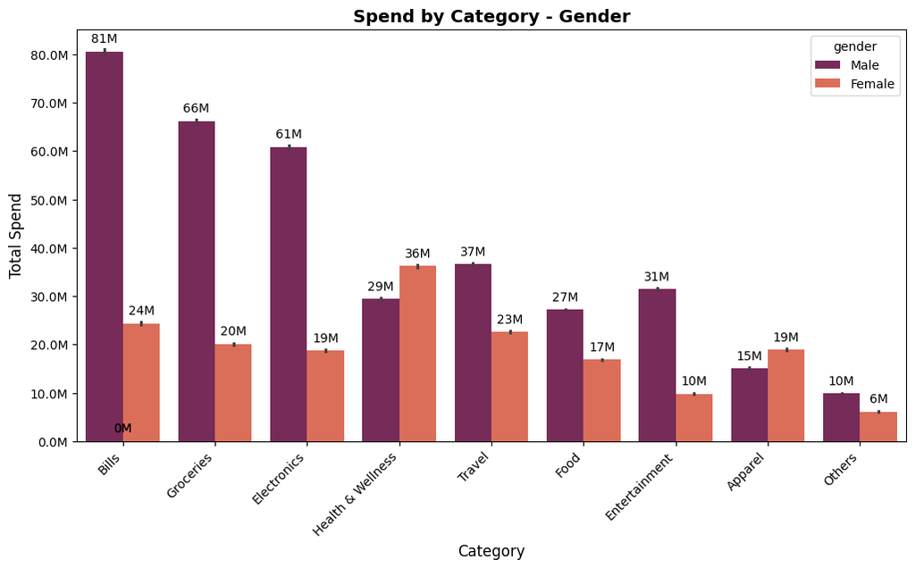

```python
plt.figure(figsize = (12,6))

spend_order = customer_spends.groupby('category')['spend'].sum().sort_values(ascending=False).index


ax = sns.barplot(data = customer_spends , x = 'category', y = 'spend',
                 estimator = sum , hue = 'gender' , palette = 'rocket' , order = spend_order )

ax.yaxis.set_major_formatter(mticker.FuncFormatter(lambda x, _: f'{x/1_000_000:.1f}M'))

annotation(ax)

# Title and labels
plt.title("Spend by Category - Gender", fontsize=14, fontweight='bold')
plt.xlabel("Category", fontsize=12)
plt.ylabel("Total Spend", fontsize=12)
plt.xticks(rotation=45, ha='right')
plt.show()
```

### **📊 Grouped Bar Chart (Total Spend by Gender across various Category)**

**Insight:** Males spend significantly more on Bills (81M), Groceries (66M), and Electronics (61M) compared to females.

Females have higher spending in Health & Wellness (36M) compared to males (29M), possibly indicating a greater focus on personal care.

Males spend significantly more on Entertainment (31M vs. 10M for females), suggesting a stronger preference for leisure activities.

In Apparel, females spend more (19M vs. 15M for males), which aligns with traditional shopping trends.

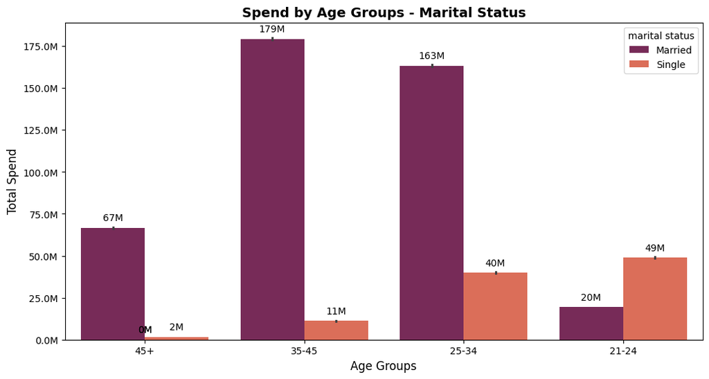

```python
order = ['45+','35-45','25-34','21-24']
plt.figure(figsize = (12,6))

ax = sns.barplot(data = customer_spends , x = 'age_group' , y = 'spend' ,
                 estimator = sum , hue = 'marital status', palette = 'rocket',order= order)

ax.yaxis.set_major_formatter(mticker.FuncFormatter(lambda x, _: f'{x/1_000_000:.1f}M'))

annotation(ax)

# Title and labels
plt.title("Spend by Age Groups - Marital Status", fontsize=14, fontweight='bold')
plt.xlabel("Age Groups", fontsize=12)
plt.ylabel("Total Spend", fontsize=12)
plt.show()
```

### **📊 Grouped Bar Chart (Total Spend by Marital Status across various Age Group)**

**Insight:** Married individuals in the 35-45 age group spend the most (179M), followed by the 25-34 group (163M).

Single individuals in the 21-24 age group spend significantly more (49M) compared to their married counterparts (20M).

The 45+ single group spends almost nothing (2M), while their married counterparts still maintain a spending level of 67M.

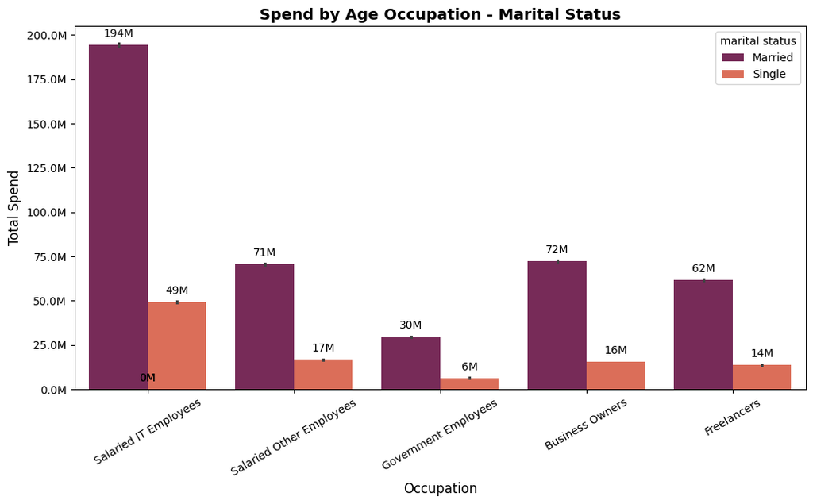

```python
plt.figure(figsize = (12,6))

ax = sns.barplot(data = customer_spends , x = 'occupation' , y = 'spend' ,
                 estimator = sum , hue = 'marital status', palette = 'rocket')

ax.yaxis.set_major_formatter(mticker.FuncFormatter(lambda x, _: f'{x/1_000_000:.1f}M'))

annotation(ax)

# Title and labels
plt.title("Spend by Age Occupation - Marital Status", fontsize=14, fontweight='bold')
plt.xlabel("Occupation", fontsize=12)
plt.ylabel("Total Spend", fontsize=12)
plt.xticks(rotation=30)
plt.show()
```

### **📊 Grouped Bar Chart (Total Spend by Marital Status across various Occupation)**

Married Salaried Other Employees (71M) spend significantly more than Single Salaried Other Employees (17M).

Government Employees show the least spending across both marital statuses, with Married spending 30M and Single spending only 6M.

Business Owners (72M) and Freelancers (62M) who are married tend to spend more compared to their single counterparts (16M and 14M, respectively).

**Note:**  
It has been difficult to plot large amounts of average salary data for 4000 customers,  
so I have divided all the average salaries into groups for better visualization.

```python
bins = [0, 10000, 20000, 30000, 40000, 50000, 60000, 70000, 80000, 90000, 100000, float("inf")]
labels = ["<10K", "10K-20K", "20K-30K", "30K-40K", "40K-50K", "50K-60K", "60K-70K",
          "70K-80K", "80K-90K", "90K-100K", ">100K"]

# Create income groups
customer_spends["avg_income_group"] = pd.cut(customer_spends["avg_income"], bins=bins, labels=labels)
```

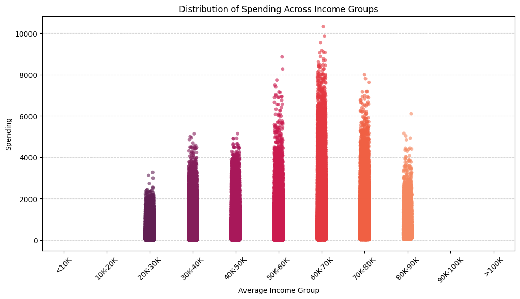

```python
# Plot the box plot
plt.figure(figsize=(12, 6))
sns.stripplot(x="avg_income_group", y="spend", data=customer_spends, jitter=True, alpha=0.6,palette = 'rocket')

# Labels & Title
plt.xlabel("Average Income Group")
plt.ylabel("Spending")
plt.title("Distribution of Spending Across Income Groups")
plt.xticks(rotation=45)  # Rotate x-axis labels for better readability
plt.grid(axis="y", linestyle="--", alpha=0.5)

plt.show()
```

### **📊 Spending Across Income Groups**

**Insight:** Higher-income groups (example- 60K-70K, 70K-80K) exhibit a wider range of spending, suggesting more variance.

Lower-income groups have more concentrated spending patterns.

```python
# Filter rows where utilisation_% is >= 10
filtered_df = customer_spends[customer_spends["utilisation_%"] >= 10]

# Count occurrences of each customer_id
count_df = filtered_df.groupby("customer_id")["utilisation_%"].count().reset_index()

# Rename the count column
count_df.rename(columns={"utilisation_%": "count"}, inplace=True)

count_df = count_df[count_df["count"] >= 3]

# Merge the filtered data with the count dataframe
result_df = filtered_df.merge(count_df, on="customer_id")

top_customer = pd.DataFrame(result_df.groupby('customer_id')['utilisation_%'].mean())
top_customer
```

| customer_id | utilisation_% |
| --- | --- |
| ATQCUS0128 | 11.863308 |
| ATQCUS0130 | 12.143805 |
| ATQCUS0144 | 11.767553 |
| ATQCUS0152 | 11.885906 |
| ATQCUS0163 | 12.594351 |
| ATQCUS0166 | 11.411514 |
| ATQCUS0170 | 11.539916 |

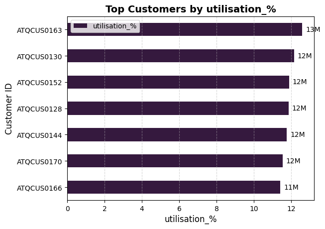

```python
plt.figure(figsize=(25, 6))

rocket_colors = sns.color_palette("rocket", 6)

ax = top_customer.sort_values('utilisation_%').plot(kind="barh", color = rocket_colors)

annotation_h(ax)

# Title and labels
plt.title("Top Customers by utilisation_%", fontsize=14, fontweight='bold')
plt.xlabel("utilisation_%", fontsize=12)
plt.ylabel("Customer ID", fontsize=12)
plt.grid(axis="x", linestyle="--", alpha=0.5)
plt.show()
```

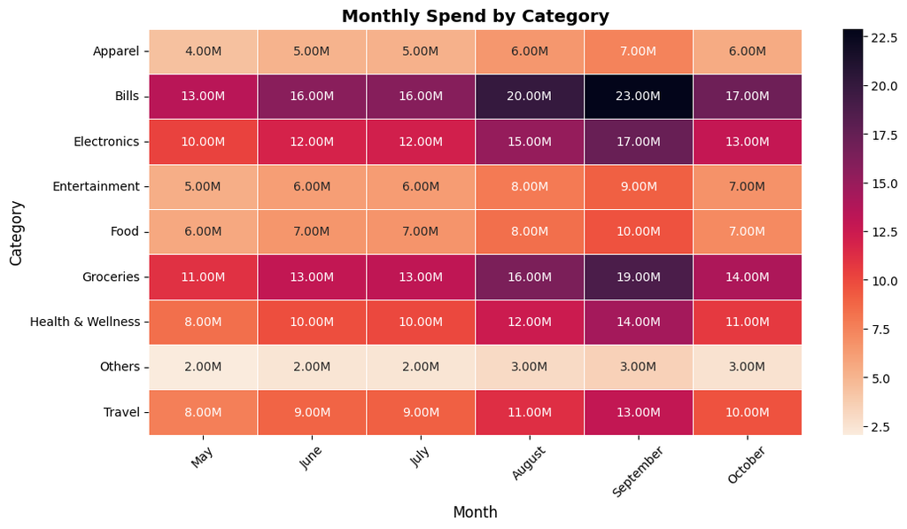

```python
order = ['May','June','July','August','September','October']

# Convert 'month' column to categorical with a specific order
customer_spends["month"] = pd.Categorical(customer_spends["month"], categories=order, ordered=True)

# Aggregate total spend per category per month
category_month_spend = customer_spends.groupby(["month", "category"])["spend"].sum().reset_index()

category_month_spend["spend"] = category_month_spend["spend"] / 1_000_000

# Pivot data for heatmap format
pivot_table = category_month_spend.pivot(index="category", columns="month", values="spend").fillna(0)

# Plot heatmap
plt.figure(figsize=(12, 6))
ax = sns.heatmap(pivot_table, cmap="rocket_r", annot=True, fmt=".0f", linewidths=0.5)

for text in ax.texts:
    text.set_text(f"{float(text.get_text()):.2f}M")

# Title and labels
plt.title("Monthly Spend by Category", fontsize=14, fontweight='bold')
plt.xlabel("Month",fontsize=12)
plt.ylabel("Category",fontsize=12)
plt.xticks(rotation=45)

plt.show()
```

### **📊 Monthly Spend by Category**

Electronics spending peaks in August and September.

"Others" category has the lowest spending across all months.

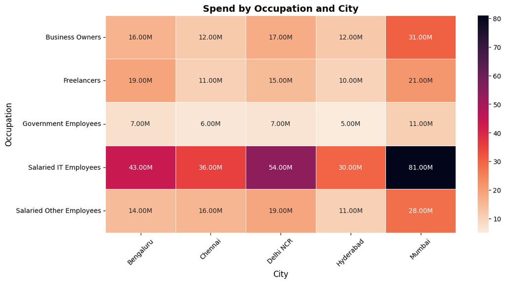

```python
# Aggregate total spend per category per month
category_month_spend = customer_spends.groupby(["occupation", "city"])["spend"].sum().reset_index()

category_month_spend["spend"] = category_month_spend["spend"] / 1_000_000

# Pivot data for heatmap format
pivot_table = category_month_spend.pivot(index="occupation", columns="city", values="spend").fillna(0)

# Plot heatmap
plt.figure(figsize=(12, 6))
ax = sns.heatmap(pivot_table, cmap="rocket_r", annot=True, fmt=".0f", linewidths=0.5)

for text in ax.texts:
    text.set_text(f"{float(text.get_text()):.2f}M")

# Title and labels
plt.title("Spend by Occupation and City", fontsize=14, fontweight='bold')
plt.xlabel("City",fontsize=12)
plt.ylabel("Occupation",fontsize=12)
plt.xticks(rotation=45)

plt.show()
```

### **📊 Spend by Occupation and City**

**Insight:** Salaried IT Employees have the highest spending, particularly in Mumbai (81M) and Delhi NCR (54M).

Freelancers and Business Owners exhibit moderate spending, with a peak in Mumbai (21M & 31M, respectively).

Government Employees have the lowest spending across all cities.

Bengaluru and Chennai show balanced spending trends across different occupations.

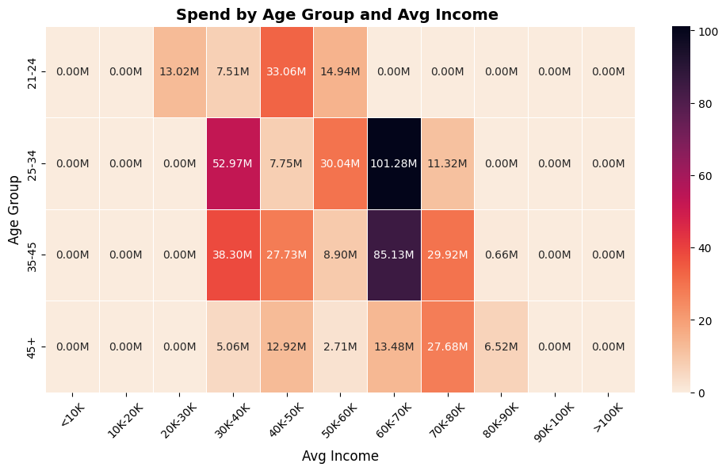

```python
# Aggregate total spend per category per month
category_month_spend = customer_spends.groupby(["age_group", "avg_income_group"])["spend"].sum().reset_index()

category_month_spend["spend"] = category_month_spend["spend"] / 1_000_000

# Pivot data for heatmap format
pivot_table = category_month_spend.pivot(index="age_group", columns="avg_income_group", values="spend").fillna(0)

# Plot heatmap
plt.figure(figsize=(12, 6))
ax = sns.heatmap(pivot_table, cmap="rocket_r", annot=True, fmt=".2f", linewidths=0.5)

for text in ax.texts:
    text.set_text(f"{float(text.get_text()):.2f}M")

# Title and labels
plt.title("Spend by Age Group and Avg Income ", fontsize=14, fontweight='bold')
plt.xlabel("Avg Income",fontsize=12)
plt.ylabel("Age Group",fontsize=12)
plt.xticks(rotation=45)

plt.show()
```

### **📊 Spend by Age Group and Avg Income**

**Insight:** The 25-34 and 35-45 age groups exhibit the highest spending across income categories, especially for individuals earning 60K-70K.

The highest spending is observed in the 25-34 age group with an income of 60K-70K (101.28M).

The 35-45 age group also shows significant spending in the 60K-70K income range (85.13M).

The 21-24 and 45+ age groups have lower spending levels, except for some moderate spending in the 30K-50K and 70K-80K income brackets.

Individuals earning below 20K or above 100K have very low or zero spending recorded, possibly due to fewer data points or different spending habits.

#### Note:

We identify customers who consistently spend 5% or more of their income across different categories.

To ensure consistency, we filter those who have maintained this spending pattern at least 3 times over 6 months.

After filtering, we extract their customer ID, spending amount, and category to analyze their spending behavior.

Finally, we aggregate the total spending per customer and category for further insights.

```python
# Filter rows where utilisation_% is >= 5
filtered_df = customer_spends[customer_spends["utilisation_%"] >= 5]

# Count occurrences of each customer_id
count_df = filtered_df.groupby("customer_id")["utilisation_%"].count().reset_index()

# Rename the count column
count_df.rename(columns={"utilisation_%": "count"}, inplace=True)

count_df = count_df[count_df["count"] >= 3]

# Merge the filtered data with the count dataframe
top_utilisation_customer = filtered_df.merge(count_df, on="customer_id")
top_utilisation_customer = top_utilisation_customer[['customer_id','spend','category']]
top_customer = top_utilisation_customer.groupby(['customer_id','category'])['spend'].sum().reset_index()
top_customer
```

|  | customer_id | category | spend |
| --- | --- | --- | --- |
| 0 | ATQCUS0001 | Electronics | 2867 |
| 1 | ATQCUS0001 | Entertainment | 23957 |
| 2 | ATQCUS0002 | Electronics | 5512 |
| 3 | ATQCUS0002 | Entertainment | 10281 |
| 4 | ATQCUS0002 | Food | 2774 |
| ... | ... | ... | ... |
| 4044 | ATQCUS3963 | Travel | 3216 |
| 4045 | ATQCUS3964 | Bills | 10217 |
| 4046 | ATQCUS3964 | Travel | 6335 |
| 4047 | ATQCUS3966 | Bills | 7133 |
| 4048 | ATQCUS3966 | Health & Wellness | 3226 |

4049 rows × 3 columns

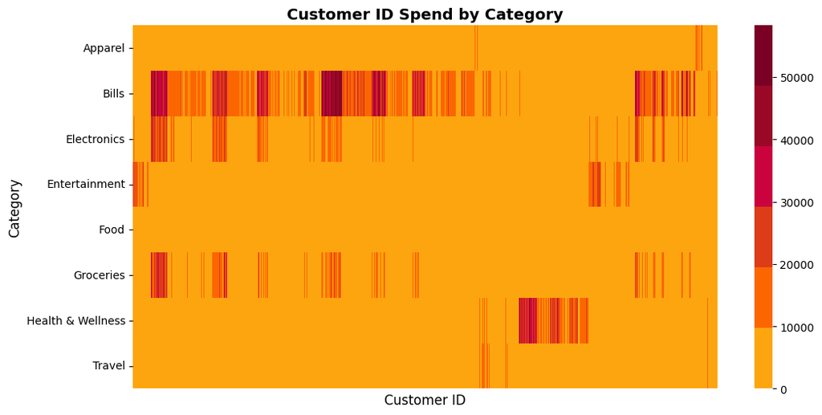

```python
pivot_table = top_customer.pivot(index="category", columns="customer_id", values="spend").fillna(0)

plt.figure(figsize = (12,6))

sns.heatmap(data = pivot_table, cmap=rocket_palette, xticklabels=False, cbar=True, linewidths=0, linecolor=None)

# Title and labels
plt.title("Customer ID Spend by Category", fontsize=14, fontweight='bold')
plt.xlabel("Customer ID",fontsize=12)
plt.ylabel("Category",fontsize=12)

plt.show()
```

### **📊 Top Customer Spending on different Category**

**Insight:** Popular Spending Categories: Categories like Bills, Electronics, and Groceries have higher concentrations of spending, suggesting these are essential or frequently used categories.

Customer Spending Behavior: Some customers show high spending across multiple categories, while others focus their spending on specific categories.

Potential Business Strategies: Understanding these high-utilization customers can help in targeted promotions, loyalty programs, and personalized offers to encourage more spending in specific categories.

# Conclusion and Recommendations for Credit Card Allocation

## Conclusion

### Payment Preferences

- Credit Cards are the most used payment method (40.7%), followed by UPI (26.5%) and Debit Cards (22.5%).
- IT Employees and Business Owners prefer digital payments like Credit Cards and UPI, while Net Banking is the least preferred mode.

### Seasonal and Category-wise Spending Trends

- Spending peaks in September and declines in October.
- Bills, Groceries, and Electronics are the top spending categories, indicating essential and lifestyle-related expenditures.
- Entertainment, Travel, and Apparel spending is higher among younger and higher-income groups.

## Recommendations for Credit Card Allocation

### 1. Target High-Income and High-Spending Customers

Prioritize Salaried IT Employees, Business Owners, and Freelancers earning 60K-80K+ per month.

Offer premium credit cards with higher limits and reward programs to high-income individuals aged 25-45.

### 2. Customized Credit Card Offers

IT Professionals & Business Owners: Offer travel rewards, cashback on digital payments, and higher credit limits.

Married Individuals (35-45 Age Group): Provide family-focused benefits, such as grocery cashback and bill payment discounts.

Freelancers & Entrepreneurs: Introduce flexible repayment plans and business-oriented benefits.

### . Focus on Digital Payment Users

Customers already using Credit Cards and UPI frequently should be offered credit limit enhancements and personalized discounts.

Introduce special offers for UPI-linked credit card transactions to encourage more spending.

### 4. Seasonal & Category-Based Promotions

Provide higher credit limits and cashback offers during peak spending months (August-September).

Offer targeted discounts in Bills, Electronics, and Grocery categories to align with major spending trends.

### 5. Low-Risk Credit Card Allocation

Avoid offering high-limit credit cards to low-income individuals (<20K) or those who exhibit inconsistent spending patterns.